# 1. Description

### Course STAT467 Multivariate Analysis

#### Semester Fall 2017

#### Content Principal Components Analysis

#### Notebook Language R

*Notes are mostly from [Applied Multivariate Statistical Analysis (Johnson et al.)](https://www1.udel.edu/oiss/pdf/617.pdf) and [PennState 505 online course](https://onlinecourses.science.psu.edu/stat505/)

```r
options(warn=-1)
library(readr)
library(ggplot2)
```

## 2. Introduction to PCA

### 2.1 Motivation behind PCA

With a large number of variables, the dispersion matrix may be too large to study and interpret properly. There would be too many pairwise correlations between the variables to consider. Graphical display of data may also not be of particular help incase the data set is very large. With 12 variables, for example, there will be more than 200 three-dimensional scatterplots to be studied!

To interpret the data in a more meaningful form, it is therefore necessary to reduce the number of variables to a few, interpretable linear combinations of the data. Each linear combination will correspond to a principal component.

### 2.2 Procedure

$$ Y_{1} = e_{11}X_1 + e_{12}X_2 + ... + e_{1p}X_p \\ Y_{2} = e_{21}X_1 + e_{22}X_2 + ... + e_{2p}X_p \\ . \\ . \\ . \\ Y_{p} = e_{p1}X_1 + e_{p2}X_2 + ... + e_{pp}X_p $$

Therefore PCA could be viewed as a variance maximization problem.

$$var(Y_i) = e_i^Tvar(X)e_i$$

There are two **constrait** of this optimization problem:

**(1)** $ e_i^Te_i = 1 $  
**(2)** $cov(e_i, e_j) = 0$

### 2.2.1 Algorithm for PCA

**I)** $\underset{e_1}{\arg\max} \ ( e_1^Tvar(X)e_1)$ and consider 1<sup>st</sup> constrait  
**II)** do $i \in 2,3,...,p$:  
$\ \ \ \ \ \ \ \ \underset{e_i}{\arg\max} \ ( e_i^Tvar(X)e_i)$ and consider 1<sup>st</sup> and 2<sup>nd</sup> constraits

### 2.2.2 Applying the algorithm

Now the question is how to maximize this with considering constraits?  
We are going to let $\lambda_1$ through $\lambda_p$ denote the eigenvalues of the $var(X)= \Sigma$. These are ordered so that $\lambda_1$ has the largest eigenvalue and $\lambda_p$ is the smallest.  
We are also going to let the eigenvectors $e_1$ through $e_p$. The variance for the ith principal component is equal to the $i_{th}$ eigenvalue. $var(Y_i)=var(e_{i1}X_1+e_{i2}X_2+. . .e_{ip}X_p)=\lambda_i$. Therefore we are going to explain total variation of X's with Y's(which is simply a linear combination of X). But the good part of Y is. They in such a form that their variation is ordered. So the first k Y could be enough to explain the variation in X (k<p). To obtain the simplest possible interpretation, we want k to be as small as possible. If we can explain most of the variation just by two principal components then this would give us a much simpler description of the data. The smaller k is the smaller amount of variation is explained by the first k component. So selecting the k requires some visualization techniques such as scree plot.

# 3. Example

Lets work on the same dataset that we analyse in [Multivariae Multiple Linear Regression](https://enesdilber.github.io/467/MMLR.html) part:

```r
data = read_csv("https://raw.githubusercontent.com/enesdilber/467/master/project/deathrate.csv", col_types = cols())
descr = read_csv("https://raw.githubusercontent.com/enesdilber/467/master/project/COLNAMES.txt", col_types = cols())

data = data[,-1]
colnames(data) = sapply(unlist(descr[,1]), function(x) substr(x, 1, regexpr(" ", x) - 1))
head(data)
```

| A1 | A2 | A3 | A4 | A5 | A6 | A7 | A8 | A9 | A10 | A11 | A12 | A13 | A14 | A15 | B |
| --- | --- | --- | --- | --- | --- | --- | --- | --- | --- | --- | --- | --- | --- | --- | --- |
| 36 | 27 | 71 | 8.1 | 3.34 | 11.4 | 81.5 | 3243 | 8.8 | 42.6 | 11.7 | 21 | 15 | 59 | 59 | 921.870 |
| 35 | 23 | 72 | 11.1 | 3.14 | 11.0 | 78.8 | 4281 | 3.6 | 50.7 | 14.4 | 8 | 10 | 39 | 57 | 997.875 |
| 44 | 29 | 74 | 10.4 | 3.21 | 9.8 | 81.6 | 4260 | 0.8 | 39.4 | 12.4 | 6 | 6 | 33 | 54 | 962.354 |
| 47 | 45 | 79 | 6.5 | 3.41 | 11.1 | 77.5 | 3125 | 27.1 | 50.2 | 20.6 | 18 | 8 | 24 | 56 | 982.291 |
| 43 | 35 | 77 | 7.6 | 3.44 | 9.6 | 84.6 | 6441 | 24.4 | 43.7 | 14.3 | 43 | 38 | 206 | 55 | 1071.289 |
| 53 | 45 | 80 | 7.7 | 3.45 | 10.2 | 66.8 | 3325 | 38.5 | 43.1 | 25.5 | 30 | 32 | 72 | 54 | 1030.380 |

```r
X = as.matrix(data[,-16])
```

```r
X.pca = prcomp(X, center = TRUE, scale. = TRUE)
round(X.pca$rotation,3) #Here is our principal component
```

|  | PC1 | PC2 | PC3 | PC4 | PC5 | PC6 | PC7 | PC8 | PC9 | PC10 | PC11 | PC12 | PC13 | PC14 | PC15 |
| --- | --- | --- | --- | --- | --- | --- | --- | --- | --- | --- | --- | --- | --- | --- | --- |
| A1 | 0.346 | 0.102 | -0.080 | 0.304 | -0.075 | 0.104 | -0.239 | 0.569 | -0.334 | 0.250 | -0.172 | 0.216 | -0.159 | -0.313 | 0.011 |
| A2 | 0.072 | -0.416 | 0.031 | 0.440 | 0.091 | 0.126 | 0.458 | -0.039 | 0.191 | 0.436 | 0.017 | 0.253 | -0.069 | 0.309 | 0.019 |
| A3 | 0.342 | -0.195 | 0.143 | 0.081 | -0.373 | -0.114 | 0.023 | 0.170 | 0.350 | -0.286 | -0.526 | -0.165 | 0.345 | 0.099 | 0.000 |
| A4 | -0.160 | 0.351 | -0.288 | 0.424 | -0.006 | -0.240 | -0.259 | 0.039 | -0.122 | 0.075 | 0.068 | -0.062 | 0.396 | 0.524 | 0.044 |
| A5 | 0.297 | 0.058 | 0.000 | -0.553 | 0.125 | 0.118 | 0.168 | -0.019 | -0.305 | 0.399 | -0.107 | 0.066 | 0.505 | 0.148 | 0.017 |
| A6 | -0.289 | -0.088 | 0.483 | -0.037 | -0.099 | 0.037 | -0.158 | 0.085 | -0.145 | -0.251 | 0.027 | 0.699 | 0.199 | 0.124 | 0.049 |
| A7 | -0.362 | -0.033 | 0.071 | -0.083 | -0.213 | 0.225 | 0.249 | 0.630 | 0.115 | 0.054 | 0.380 | -0.298 | 0.225 | -0.039 | -0.025 |
| A8 | -0.067 | -0.105 | -0.434 | 0.156 | -0.411 | 0.413 | 0.258 | -0.276 | -0.396 | -0.295 | -0.028 | 0.073 | 0.148 | -0.132 | -0.007 |
| A9 | 0.299 | -0.382 | 0.044 | -0.115 | 0.042 | 0.223 | -0.278 | 0.129 | -0.273 | -0.254 | 0.234 | -0.224 | -0.267 | 0.537 | 0.018 |
| A10 | -0.197 | -0.195 | 0.401 | 0.150 | -0.314 | 0.139 | -0.382 | -0.324 | -0.164 | 0.445 | -0.066 | -0.344 | 0.082 | -0.128 | -0.030 |
| A11 | 0.356 | -0.269 | 0.015 | 0.217 | 0.199 | -0.149 | -0.133 | -0.114 | 0.063 | -0.128 | 0.547 | 0.019 | 0.447 | -0.375 | -0.004 |
| A12 | -0.286 | -0.403 | -0.153 | -0.032 | 0.236 | -0.250 | 0.003 | 0.118 | -0.209 | -0.027 | -0.231 | -0.118 | 0.058 | -0.125 | 0.685 |
| A13 | -0.271 | -0.409 | -0.222 | -0.057 | 0.210 | -0.229 | -0.085 | 0.126 | -0.150 | 0.000 | -0.213 | 0.006 | 0.080 | -0.047 | -0.715 |
| A14 | -0.069 | -0.184 | -0.469 | -0.256 | -0.169 | 0.239 | -0.468 | 0.001 | 0.489 | 0.206 | 0.050 | 0.273 | 0.024 | 0.009 | 0.114 |
| A15 | -0.098 | 0.115 | 0.088 | 0.193 | 0.583 | 0.635 | -0.127 | 0.005 | 0.142 | -0.163 | -0.268 | -0.122 | 0.193 | -0.048 | -0.014 |

```r
summary(X.pca) #With first 9 PC we could explain the variation by 95%
```

```
Importance of components:
                          PC1    PC2    PC3     PC4    PC5     PC6     PC7
Standard deviation     2.1278 1.6006 1.4147 1.19022 1.0982 0.99734 0.85842
Proportion of Variance 0.3018 0.1708 0.1334 0.09444 0.0804 0.06631 0.04913
Cumulative Proportion  0.3018 0.4726 0.6060 0.70049 0.7809 0.84721 0.89634
                           PC8     PC9    PC10    PC11    PC12    PC13    PC14
Standard deviation     0.68422 0.59707 0.50091 0.40292 0.37682 0.33970 0.23413
Proportion of Variance 0.03121 0.02377 0.01673 0.01082 0.00947 0.00769 0.00365
Cumulative Proportion  0.92755 0.95131 0.96804 0.97886 0.98833 0.99602 0.99968
                          PC15
Standard deviation     0.06968
Proportion of Variance 0.00032
Cumulative Proportion  1.00000
```

## 3.1 Scree Plot

To decideng the stopping point for PCA one can observe the decreasing of eigenvalues(variance of Y's).

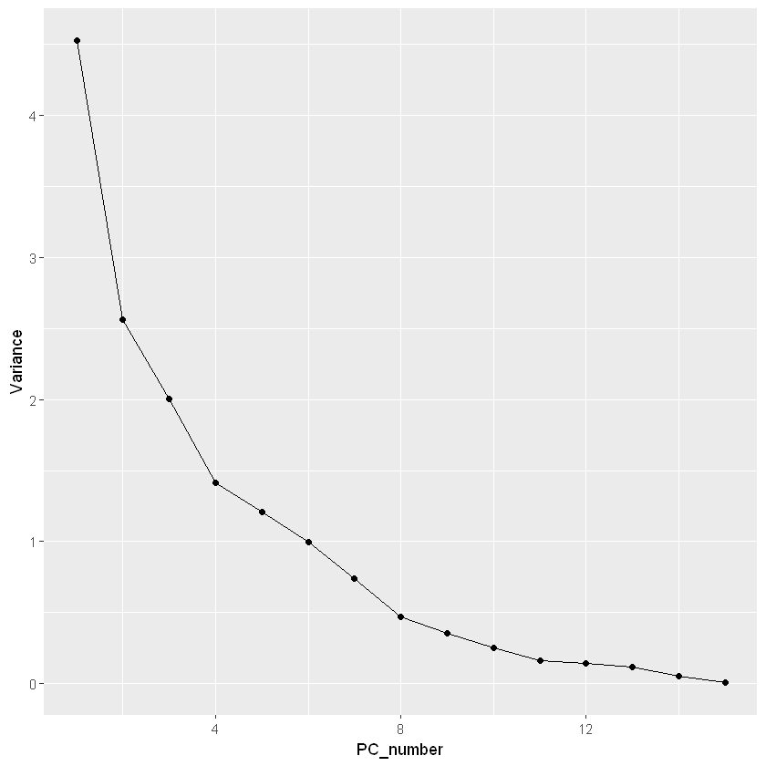

```r
eigenValues = (X.pca$sdev)^2
df = data.frame(PC_number = 1:length(eigenValues), Variance = eigenValues)
ggplot(df, aes(PC_number, y = Variance))+geom_line()+geom_point()
```

## 3.2 Interpretation of PC's

To interpret each component, we must compute the correlations between the original data for each variable and each principal component.

```r
transferedX = X%*%(X.pca$rotation) #compute transfered values (Y)
```

```r
round(apply(transferedX, 2, function(x) apply(X, 2, function(t) cor(t,x))), 3) #find the correlation between X's and Y's
```

|  | PC1 | PC2 | PC3 | PC4 | PC5 | PC6 | PC7 | PC8 | PC9 | PC10 | PC11 | PC12 | PC13 | PC14 | PC15 |
| --- | --- | --- | --- | --- | --- | --- | --- | --- | --- | --- | --- | --- | --- | --- | --- |
| A1 | 0.250 | 0.165 | 0.026 | 0.035 | -0.022 | 0.024 | 0.002 | -0.005 | 0.016 | 0.005 | 0.277 | 0.050 | -0.033 | 0.036 | -0.542 |
| A2 | -0.228 | -0.289 | -0.197 | 0.231 | -0.181 | 0.184 | 0.220 | -0.188 | -0.216 | -0.196 | -0.310 | 0.164 | 0.205 | -0.196 | 0.204 |
| A3 | 0.239 | 0.141 | 0.076 | -0.032 | 0.040 | -0.043 | -0.053 | 0.052 | 0.070 | 0.060 | 0.237 | -0.029 | -0.078 | 0.093 | -0.337 |
| A4 | -0.162 | -0.107 | -0.160 | 0.164 | -0.162 | 0.160 | 0.164 | -0.163 | -0.163 | -0.162 | -0.139 | 0.162 | 0.165 | -0.178 | -0.090 |
| A5 | 0.324 | 0.276 | 0.192 | -0.184 | 0.164 | -0.163 | -0.192 | 0.173 | 0.202 | 0.183 | 0.372 | -0.135 | -0.205 | 0.212 | -0.321 |
| A6 | 0.080 | 0.144 | 0.241 | -0.248 | 0.260 | -0.262 | -0.232 | 0.251 | 0.225 | 0.240 | 0.030 | -0.308 | -0.227 | 0.224 | 0.341 |
| A7 | -0.349 | -0.273 | -0.195 | 0.159 | -0.165 | 0.165 | 0.182 | -0.169 | -0.192 | -0.181 | -0.342 | 0.134 | 0.203 | -0.208 | 0.350 |
| A8 | -0.923 | -0.938 | -0.998 | 0.996 | -0.999 | 0.999 | 0.997 | -0.999 | -0.999 | -1.000 | -0.838 | 0.990 | 0.999 | -0.998 | -0.150 |
| A9 | 0.068 | -0.037 | -0.001 | -0.006 | 0.002 | 0.002 | -0.025 | 0.010 | 0.011 | 0.009 | 0.040 | 0.022 | -0.014 | 0.026 | -0.015 |
| A10 | -0.061 | -0.039 | 0.030 | -0.031 | 0.040 | -0.041 | -0.028 | 0.034 | 0.020 | 0.033 | -0.086 | -0.075 | -0.020 | 0.022 | 0.219 |
| A11 | 0.258 | 0.153 | 0.167 | -0.138 | 0.159 | -0.157 | -0.162 | 0.163 | 0.164 | 0.164 | 0.204 | -0.137 | -0.173 | 0.183 | -0.098 |
| A12 | -0.483 | -0.447 | -0.166 | 0.076 | -0.072 | 0.072 | 0.099 | -0.086 | -0.150 | -0.116 | -0.639 | 0.056 | 0.164 | -0.178 | 0.955 |
| A13 | -0.522 | -0.493 | -0.216 | 0.113 | -0.120 | 0.121 | 0.135 | -0.131 | -0.189 | -0.159 | -0.663 | 0.119 | 0.210 | -0.222 | 0.923 |
| A14 | -0.522 | -0.542 | -0.479 | 0.356 | -0.432 | 0.437 | 0.358 | -0.421 | -0.400 | -0.412 | -0.458 | 0.520 | 0.447 | -0.444 | 0.215 |
| A15 | 0.072 | 0.100 | 0.096 | -0.083 | 0.099 | -0.087 | -0.087 | 0.091 | 0.091 | 0.092 | 0.071 | -0.100 | -0.091 | 0.092 | 0.018 |

One could interpret a PC by grouping variables that are highly correlated with that given PC.